# Systems Integration

Mapping Languages

Prof. Dr. Christian Drumm

10.11.2026

# Overview

## Mapping Languages

Transforming data between structures and formats

- Query languages **retrieve** data — mapping languages **transform** it
- Mapping languages convert data from one format or structure into another
- Essential in **data integration** scenarios where systems use different formats
- Three languages are covered in this lecture:
  - **SQL** — transformation features beyond plain querying
  - **XSLT** — the standard language for transforming XML
  - **jq** — a widely used filter language for transforming JSON
- Mapping languages operate on the **syntactic level** of interoperability

## Learning Objectives

After this lecture, you should be able to:

- Describe the transformation concepts **shared** by all three languages: reshaping, filtering, and aggregating data
- Distinguish the three **transformation paradigms**: set-based SQL, template-based XSLT, and filter pipelines in jq
- Apply SQL’s **set-based transformations** in the database, including native XML and JSON generation
- Explain why database implementations **deviate from the SQL standard**
- Write **XSLT stylesheets** based on the template processing model, including XSLT 3.0’s built-in **XML ⇄ JSON** conversion
- Compose **jq filter pipelines** to reshape, aggregate, and export JSON data
- Select the **appropriate mapping language** for a given integration scenario

## Querying vs. Mapping

### Two complementary capabilities

| Aspect | Query languages | Mapping languages |
| --- | --- | --- |
| **Goal** | Retrieve and filter data | Transform and restructure data |
| **Input** | Database, XML document, JSON | Documents or tables in one format |
| **Output** | The requested data | Data in a *new* format or structure |

### The languages of this lecture

| Language | Query language role | Mapping language role |
| --- | --- | --- |
| **SQL** | `SELECT` statements | Joins, CTEs, `XMLELEMENT`, `JSON_OBJECT` |
| **XSLT** | XPath path expressions | Templates, `fn:xml-to-json` |
| **jq** | Filters, e.g. `select(.price > 100)` | Object and array construction, `map`, `@csv` |

> In practice, both concepts overlap: a query can already transform, and a mapping frequently queries its input.

# Data Transformation with SQL

## SQL as a Mapping Language

More than querying

- SQL was introduced in the previous lecture as a **query language**
- SQL also provides extensive functionality for **transforming** data:
  - reshaping tables and combining data
  - summarizing and analyzing data
  - generating **XML** and **JSON** output inside the database
- This makes SQL a powerful tool for **ETL** and **mapping** scenarios

## Structural Transformation

Reshaping data with joins, subqueries, and CTEs

- SQL provides several features to transform and reorganize data structures:
  - **Joins** — combine data from multiple tables
  - **Subqueries** — nest queries for flexible filtering
  - **Common Table Expressions (CTEs)** — structure complex queries into manageable parts
- These features allow you to reshape tables, combine datasets, and build complex mappings within a single statement

## Joins

Combining data from multiple tables

- Joins merge tables based on **related keys**
- **Inner Join** — rows with a match in both tables
- **Left / Right Join** — all rows from one side, matched rows from the other; non-matches return `NULL`
- **Full Outer Join** — rows with a match in either table or both

```sql
SELECT p.name, p.price, c.category_name
FROM Products AS p
INNER JOIN Categories AS c
ON p.category_id = c.category_id;
```

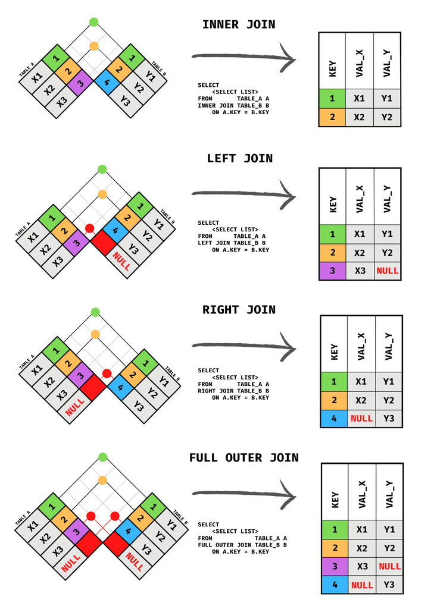

Diagram: A. Martinson, [“You Should Use This to Visualize SQL Joins Instead of Venn Diagrams”](https://towardsdatascience.com/you-should-use-this-to-visualize-sql-joins-instead-of-venn-diagrams-ede15f9583fc/)_

## Subqueries

Nesting queries for flexibility

- Subqueries nest one query inside another
- Useful when conditions depend on values from a secondary query:

| Type | Returns | Used in |
| --- | --- | --- |
| **Scalar subquery** | a single value | `SELECT` list or `WHERE` clause |
| **Table subquery** | a result set | `FROM` clause |

```sql
SELECT name, price
FROM Products
WHERE price > (SELECT AVG(price) FROM Products);
```

> Retrieves all products **more expensive than the average** product — the subquery computes the threshold.

## Common Table Expressions (CTEs)

Structuring complex queries

- CTEs break complex queries into **smaller, reusable parts**
- Defined with the `WITH` clause; can be referenced multiple times
- Particularly useful for **recursion** and **hierarchical data**

```sql
WITH InventoryValueSummary AS (
  SELECT category_id,
         SUM(price * stock) AS total_inventory_value
  FROM Products
  GROUP BY category_id
)

SELECT c.category_name, ivs.total_inventory_value
FROM InventoryValueSummary ivs
INNER JOIN Categories c ON ivs.category_id = c.category_id;
```

> The CTE computes inventory values per category; the main query adds readable category names.

## Aggregate Functions

Summarizing data

- SQL’s aggregate functions summarize data:

| Function | Purpose |
| --- | --- |
| **`COUNT()`** | counts rows or non-null values |
| **`SUM()`** | sums numeric values |
| **`AVG()`** | calculates the average of a column |
| **`MAX()` / `MIN()`** | highest and lowest values |

```sql
SELECT c.category_name,
       COUNT(p.id) AS number_of_products,
       AVG(p.price) AS average_price,
       SUM(p.price * p.stock) AS total_inventory_value
FROM Products p
JOIN Categories c ON p.category_id = c.category_id
GROUP BY c.category_name;
```

## Window Functions

Advanced analysis

- Window functions calculate across a set of rows **related to the current row**
- Useful for **running totals**, **ranking**, and analytical queries

```sql
SELECT name, price,
       RANK() OVER (ORDER BY price DESC) AS rank
FROM Products;
```

**Result:**

| name | price | rank |
| --- | --- | --- |
| Laptop | 1500 | 1 |
| Smartphone | 1000 | 2 |
| Headphones | 200 | 3 |

> The function operates over a **window** of rows; each row keeps its own context.

## SQL:2003 — Generating XML

Relational data to XML

- Since **SQL:2003**, the standard supports an XML datatype and XML functions:

| Function | Purpose |
| --- | --- |
| **`XMLELEMENT`** | creates an XML element with a name and content |
| **`XMLAGG`** | aggregates XML elements into one document |
| **`XMLFOREST`** | creates a forest of elements from columns |
| **`XMLQUERY()`** | extracts data from XML via XPath-like expressions |

```sql
SELECT XMLELEMENT(NAME "products",
         XMLAGG(
           XMLELEMENT(NAME "product",
             XMLFOREST(id AS "id", name AS "name", price AS "price"))))
FROM Products;
```

```xml
<products>
  <product><id>1</id><name>Mountain Bike</name><price>1200</price></product>
  <product><id>2</id><name>Helmet</name><price>50</price></product>
</products>
```

## SQL:2016 — Generating JSON

Relational data to JSON

- Since **SQL:2016**, the standard converts relational data into **JSON**; since **SQL:2023** it also defines a JSON datatype

| Function | Purpose |
| --- | --- |
| **`JSON_OBJECT`** | creates a JSON object from key-value pairs |
| **`JSON_ARRAYAGG`** | aggregates values into a JSON array |
| **`JSON_VALUE()`** | extracts scalar values from JSON columns |
| **`OPENJSON()`** | parses JSON data into relational format |

```sql
SELECT JSON_ARRAYAGG(
         JSON_OBJECT('id' VALUE id,
                     'name' VALUE name,
                     'price' VALUE price))
FROM Products;
```

```json
[
  { "id": 1, "name": "Mountain Bike", "price": 1200 },
  { "id": 2, "name": "Helmet", "price": 50 }
]
```

## Database-specific Implementations

When systems deviate from the standard

- Not all systems implement the latest SQL standards
- Many databases provide **proprietary functions** tailored to their architecture
- Example **DuckDB** — an in-process analytical database:

```sql
-- DuckDB-specific JSON functions
SELECT json_group_array(
         json_object('id', id,
                     'name', name,
                     'price', price))
FROM Products;
```

- `json_group_array` and `json_object` replace `JSON_ARRAYAGG` and `JSON_OBJECT`
- Same mapping, different syntax — similar variations exist for XML functions

> In integration projects, always check the **actual implementation** of your database system.

## PIVOT in DuckDB

A powerful, non-standard transformation

- `PIVOT` turns rows into columns — a high-level transformation **not part of the SQL standard**
- DuckDB requires pivoted data to be prepared in a **CTE**

```sql
WITH InventoryValueSummary AS (
    SELECT c.category_name,
           p.price * p.stock AS inventory_value
    FROM Products p
    JOIN Categories c ON p.category_id = c.category_id
)
PIVOT InventoryValueSummary
ON category_name
USING SUM(inventory_value) AS total_inventory_value;
```

**Result:**

| Outdoor | Electronics | Accessories |
| --- | --- | --- |
| 16500.00 | 75000.00 | 6250.00 |

# XSLT

## XSLT — Introduction

Extensible Stylesheet Language Transformations

- A powerful language specifically designed for **transforming XML documents**
- In data integration, XSLT transforms data from **one XML schema to another**
- Also used to generate **HTML**, **JSON**, or plain text from XML
- Transformation rules are defined in **templates**, selected via **XPath** expressions
- W3C standard — current version **XSLT 3.0**

> XSLT relies on **XPath** for selecting and manipulating parts of the XML document.

## XSLT — Processing Model

Templates define the transformation

- A stylesheet consists of **templates** — rules for transforming specific elements
- Core instructions:
  - **`<xsl:template match="...">`** — defines how matching elements are transformed
  - **`<xsl:apply-templates>`** — processes elements based on matching templates
  - **`<xsl:value-of select="..."/>`** — retrieves the text value of elements and attributes
- XPath expressions drive the matching and selection

## XSLT — Running Example

- The same source document is used for all subsequent examples

```xml
<Products>
  <Product>
    <Name>Mountain Bike</Name>
    <Price>1200</Price>
  </Product>
  <Product>
    <Name>Helmet</Name>
    <Price>50</Price>
  </Product>
</Products>
```

## XSLT — Template-Based Example

Transforming one XML schema to another

### Stylesheet

```xml
<xsl:stylesheet version="1.0"
    xmlns:xsl="http://www.w3.org/1999/XSL/Transform">
  <xsl:template match="/">
    <TransformedData>
      <xsl:apply-templates
        select="Products/Product" />
    </TransformedData>
  </xsl:template>

  <xsl:template match="Product">
    <Item>
      <Name><xsl:value-of select="Name" /></Name>
      <Price><xsl:value-of select="Price" /></Price>
    </Item>
  </xsl:template>
</xsl:stylesheet>
```

### Output

```xml
<TransformedData>
  <Item>
    <Name>Mountain Bike</Name>
    <Price>1200</Price>
  </Item>
  <Item>
    <Name>Helmet</Name>
    <Price>50</Price>
  </Item>
</TransformedData>
```

- The root template (`/`) creates `<TransformedData>` and applies templates to all `Product` elements
- Each `Product` becomes an `<Item>` with `Name` and `Price` extracted via `<xsl:value-of>`

## XSLT — Conditional Logic

`xsl:if` and `xsl:choose`

- Conditional structures enable **selective transformation** based on data content
- Essential when parts of a document need different treatment

```xml
<xsl:template match="Product">
  <Item>
    <Name><xsl:value-of select="Name" /></Name>
    <xsl:if test="Price > 100">
      <Price><xsl:value-of select="Price" /></Price>
    </xsl:if>
  </Item>
</xsl:template>
```

**Result:**

```xml
<Item><Name>Mountain Bike</Name><Price>1200</Price></Item>
<Item><Name>Helmet</Name></Item>
```

> The `Price` element is only included when the price exceeds 100.

## XSLT — Iteration and Sorting

`xsl:for-each` and `xsl:sort`

- **`xsl:for-each`** loops over elements to transform multiple parts of the document
- **`xsl:sort`** sorts the XML data before it is transformed

```xml
<xsl:template match="/">
  <TransformedData>
    <xsl:for-each select="Products/Product">
      <xsl:sort select="Price" order="ascending" />
      <Item>
        <Name><xsl:value-of select="Name" /></Name>
        <Price><xsl:value-of select="Price" /></Price>
      </Item>
    </xsl:for-each>
  </TransformedData>
</xsl:template>
```

> Products are sorted by `Price` before being transformed into `Item` elements.

## XSLT — XML to JSON (Manually)

Constructing text output

- XSLT is a general-purpose transformation language — it can also emit **JSON** as text

```xml
<xsl:stylesheet version="1.0"
    xmlns:xsl="http://www.w3.org/1999/XSL/Transform">
  <xsl:output method="text" />
  <xsl:template match="/">
    { "products": [
      <xsl:for-each select="Products/Product">
        { "name": "<xsl:value-of select='Name'/>",
          "price": <xsl:value-of select='Price'/> }<xsl:if
          test="position() != last()">,</xsl:if>
      </xsl:for-each>
    ] }
  </xsl:template>
</xsl:stylesheet>
```

- JSON is built **manually** as plain text
- `<xsl:if>` handles the commas between array elements

## XSLT 3.0 — `fn:xml-to-json`

Built-in XML to JSON conversion

- Since **XSLT 3.0**, the built-in function `fn:xml-to-json()` converts XML to JSON directly:
  - `$input-node` — the XML node or subtree to convert
  - `$options` — optional handling of elements, attributes, pretty-printing
- The result is guaranteed to be **well-formed JSON**

```xml
<xsl:stylesheet version="3.0"
    xmlns:xsl="http://www.w3.org/1999/XSL/Transform">
  <xsl:output method="text" />
  <xsl:template match="/">
    <xsl:value-of select="fn:xml-to-json(.)" />
  </xsl:template>
</xsl:stylesheet>
```

> The XML tree is automatically mapped to the equivalent JSON format — no manual formatting, no comma handling.

## XSLT 3.0 — `fn:json-to-xml`

Built-in JSON to XML conversion

- The reverse function `fn:json-to-xml()` converts **JSON into XML**
- Useful when systems deliver JSON but the pipeline processes XML

### Input JSON

```json
{
  "Products": {
    "Product": [
      { "Name": "Mountain Bike", "Price": 1200 },
      { "Name": "Helmet", "Price": 50 }
    ]
  }
}
```

### Resulting XML (excerpt)

```xml
<map:map xmlns:map="http://www.w3.org/
                   2005/xpath-functions">
  <map:string key="Products">
    <map:map>
      <map:string key="Product">
        <map:array>
          <map:map>
            <map:string key="Name">
              Mountain Bike</map:string>
            <map:number key="Price">1200
              </map:number>
          </map:map>
          ...
        </map:array>
      </map:string>
    </map:map>
  </map:string>
</map:map>
```

> The JSON is represented as XML in the `map:` namespace; it can then be processed with any XSLT transformation.

## XSLT — Advanced XPath Constructs

Filtering on calculated conditions

- XPath **predicates** allow complex selection logic
- Task: include only items whose total price (`Price * Quantity`) exceeds 1000

```xml
<xsl:template match="Order">
  <Order id="{@id}">
    <Customer><xsl:value-of select="Customer" /></Customer>
    <xsl:apply-templates
      select="Items/Item[Price * Quantity &gt; 1000]" />
  </Order>
</xsl:template>

<xsl:template match="Item">
  <Item>
    <Name><xsl:value-of select="Name" /></Name>
    <TotalPrice><xsl:value-of select="Price * Quantity" /></TotalPrice>
  </Item>
</xsl:template>
```

> The predicate `Items/Item[Price * Quantity > 1000]` filters items by a **calculated condition**; the total price is computed and output as `<TotalPrice>`.

## XSLT — Exercise

Writing XSLT Stylesheets

In this exercise, you will write XSLT stylesheets to transform a product catalog XML document.

- **Exercise 1 — XML-to-XML**: transform the catalog into a new structure (`Product`/`ProductName`/`Price` → `Item`/`Name`/`Cost`)
- **Exercise 2 — XML-to-JSON**: transform the same catalog into JSON with a `catalog` array
- Check your results with an XSLT processor
  - [xsltransform.net](https://xsltransform.net/)
  - codebeautify.org/Xslt-Tester
- Use the [input documents](https://codeberg.org/ceedee666/systems-integration/src/branch/main/lectures/mapping-languages.md#exercises) from the lecture notes as a basis

> Work in pairs and compare your stylesheets.

## XSLT — Key Takeaways

- XSLT is a versatile tool for **transforming XML** in integration scenarios
- **Template-based transformation** allows selective processing of elements
- **Conditional logic** and **looping** control how the output is structured
- XSLT handles both **XML-to-XML** and **XML-to-JSON** conversions
  - XSLT 3.0 provides built-in `fn:xml-to-json()` and `fn:json-to-xml()`
- **Advanced XPath expressions** enable complex filtering, e.g. on calculated conditions

# jq

## jq — Transformation Features

Reshaping and converting JSON

- jq was introduced as a **query language** for JSON — every jq program is a **filter**
- Filters can also **transform** JSON:
  - **Object** `{...}` and **array** `[...]` construction reshape documents
- Built-ins: `map`, `select`, `group_by`, `sort_by`, `add`, `del`
- Operators: `+` (add fields), `|=` / `+=` (update), `del()` (remove)
- Output formatters: `@csv`, `@tsv`, and `-r` raw output

> jq is the most widely used tool for transforming JSON in integration pipelines.

## jq — Running Example

The JSON document used throughout this section

```json
{
  "products": [
    {
      "id": 1,
      "name": "Mountain Bike",
      "category": "Outdoor",
      "price": 1200,
      "stock": 10
    },
    {
      "id": 2,
      "name": "Helmet",
      "category": "Accessories",
      "price": 50,
      "stock": 100
    },
    {
      "id": 3,
      "name": "Gloves",
      "category": "Accessories",
      "price": 25,
      "stock": 50
    }
  ]
}
```

## jq — Constructing New JSON

Object and array construction

### Filter

```
[.products[] |
  {name: .name, cost: .price}]
```

### Output

```json
[
  { "name": "Mountain Bike", "cost": 1200 },
  { "name": "Helmet", "cost": 50 },
  { "name": "Gloves", "cost": 25 }
]
```

- `.products[]` iterates over all products
- The object construction **renames** keys (`price` → `cost`) and drops all other fields
- `[...]` collects all results into a single JSON array

## jq — Transforming and Enriching

Built-ins and operators

| Built-in / Operator | Purpose | Example |
| --- | --- | --- |
| **`map(f)`** | apply `f` to every element | `.products \\| map(.price)` → `[1200, 50, 25]` |
| **`select(f)`** | keep elements where `f` is true | `select(.price > 100)` |
| **`+`** | add or merge fields | `. + {value: (.price * .stock)}` |
| **`del(path)`** | remove fields or elements | `del(.id)` |
| **`add` / `length`** | aggregate values | `map(.price) \\| add` → `1275` |

```
[.products[] | select(.price > 100)
              | . + {inventory_value: (.price * .stock)}]
```

> The filter keeps products above a price of 100 and enriches them with a **calculated** `inventory_value` field.

## jq — Grouping and Aggregating

The jq equivalent of SQL `GROUP BY`

```
.products
| group_by(.category)
| map({category: .[0].category,
       number_of_products: length,
       total_inventory_value: (map(.price * .stock) | add)})
```

**Output:**

```json
[
  {
    "category": "Accessories",
    "number_of_products": 2,
    "total_inventory_value": 6250
  },
  {
    "category": "Outdoor",
    "number_of_products": 1,
    "total_inventory_value": 12000
  }
]
```

- `group_by(.category)` produces one sub-array per category
- `map(...)` transforms each group into a summary object
- `map(.price * .stock) | add` aggregates the inventory value per group

## jq — Output Beyond JSON

Exporting to CSV, TSV, and raw text

- **`@csv`** / **`@tsv`** format an array as a CSV / TSV row
- **`-r`** prints strings raw, without quotes

```bash
jq -r '.products[] | [.name, .price] | @csv' products.json
```

**Output:**

```
"Mountain Bike",1200
"Helmet",50
"Gloves",25
```

> Useful to hand JSON data to systems that do not consume JSON — e.g. spreadsheets, relational ETL tools, or shell scripts.

## jq — Exercise

Transforming and Exporting JSON

In this exercise, you will write jq filters to transform a product catalog JSON document.

- **Exercise 3 — JSON-to-JSON**: extract all products with a price above 100 into a new structure (`catalog` array with `name` and `price`)
- **Exercise 4 — JSON-to-CSV**: export all products as CSV, sorted by price descending
- Check your results with [jq play](https://jqplay.org/) or locally: `jq '<filter>' products.json`
- Use the [input document](https://codeberg.org/ceedee666/systems-integration/src/branch/main/lectures/mapping-languages.md#jq-transforming-json-data) from the lecture notes as a basis

> Recall: `sort_by()` sorts arrays and `@csv` formats rows.

## jq — Key Takeaways

- jq is a **filter language** that queries **and transforms** JSON
- **Object and array construction** reshape documents; `+`, `|=`, and `del()` modify fields
- Built-ins such as `map`, `select`, `group_by`, and `sort_by` process collections
- **`@csv`** and **`@tsv`** export data for non-JSON consumers
- Widely used in integration pipelines to adapt JSON messages between systems

# Summary

## Summary

- **Mapping languages** transform data between formats and structures — essential for systems integration
- **SQL** goes beyond querying:
  - Structural transformation with **joins**, **subqueries**, and **CTEs**
  - Summarization with **aggregate** and **window functions**
  - Native **XML** (SQL:2003) and **JSON** (SQL:2016) generation
  - Implementations deviate from the standard, e.g. proprietary functions in **DuckDB**
- **XSLT** transforms XML via **templates** and **XPath**:
  - Conditional logic, iteration, and sorting
  - XML-to-XML and XML-to-JSON, with built-in functions in XSLT 3.0
- **jq** transforms JSON with **filters**:
  - Object and array construction reshape documents; `map`, `select`, `group_by`, and `sort_by` process collections
  - `@csv` and `@tsv` export JSON data for non-JSON consumers

## SQL vs. XSLT vs. jq

Three languages, three data models

| Aspect | SQL | XSLT | jq |
| --- | --- | --- | --- |
| **Data model** | Relational tables | XML node tree | JSON values |
| **Transformation paradigm** | Declarative, set-based operations | Rule-based templates driven by XPath | Functional filter pipelines |
| **Typical input** | Relational tables | XML documents | JSON values |
| **Typical output** | Tables, XML, JSON | XML, JSON, HTML, plain text | JSON, CSV, TSV, plain text |
| **Core constructs** | `JOIN`, subqueries, CTEs, `GROUP BY`, `XMLELEMENT` | `xsl:template`, `xsl:if`, `xsl:for-each`, `fn:xml-to-json` | Object/array construction, `map`, `select`, `@csv` |
| **Standardization** | ISO/IEC 9075 (incl. SQL/XML, JSON functions) | W3C standard, version 3.0 | Not standardized, de facto standard tool |
| **Integration use** | ETL and mapping inside the database | Message mapping between XML systems | Adapting JSON in pipelines |

> The languages are **complementary**: SQL transforms data inside the database, XSLT maps XML-centric systems, and jq adapts the JSON exchanged by modern APIs — often used in combination.

## Case Study: BikeERP and its Partners

One product catalog, three systems, three data formats

### BikeERP

- Manages the product catalog in a **relational database**
- Tables: `Products`, `Categories`

### BikeShop24

- The **web shop**, sells online
- Reads the catalog from a REST API
- Expects data in **JSON**

### PartsHub

- A **supplier portal**, legacy system
- Demands weekly price lists as **XML**

### Required data flows

- ERP → shop: publish the full catalog as **JSON**
- ERP → supplier: deliver the price list as **XML**

## References

- Lecture notes: Mapping Languages
- Wikipedia, *SQL/XML* [SQL:2003 XML features](https://en.wikipedia.org/wiki/SQL/XML)
- Wikipedia, *SQL:2016* [SQL:2016 JSON features](https://en.wikipedia.org/wiki/SQL:2016)
- W3C, *XSL Transformations (XSLT) Version 3.0* [W3C Recommendation](https://www.w3.org/TR/xslt-30/)
- W3C, *XPath and XQuery Functions and Operators 3.1* [`fn:xml-to-json`, `fn:json-to-xml`](https://www.w3.org/TR/xpath-functions-31/)
- jq, *Manual* [jqlang.github.io/jq](https://jqlang.github.io/jq/manual/)
- jq play [jqplay.org](https://jqplay.org/)
- DuckDB, *JSON Extension* and *PIVOT* [duckdb.org/docs](https://duckdb.org/docs/stable/extensions/json)
- DuckDB [duckdb.org](https://duckdb.org/)
- A. Martinson, “You Should Use This to Visualize SQL Joins Instead of Venn Diagrams”, *Towards Data Science*, 2022. [Article](https://towardsdatascience.com/you-should-use-this-to-visualize-sql-joins-instead-of-venn-diagrams-ede15f9583fc/)